# Tame Your Data With R: ADVANCE Workshop 2

Elizabeth E. Esterly

December 4th, 2017, University of New Mexico

## Getting Started

Download these datasets to your desktop. DATASET 1: http://cs.unm.edu/~elizabeth/newSuperheroes.csv  
DATASET 2: http://cs.unm.edu/~elizabeth/newCharacteristics.csv

```r
#Load the Tidyverse
library(tidyverse)
```

```r
#Read in the superhero data
super <- read_csv('newSuperheroes.csv')
```

## Transform

We’ll bring in a second dataset here, transform it, and then transform our original dataset by doing some different joins of these two datasets.

```r
#Import the second set and take a look at the first few rows
second <- read_csv('newCharacteristics.csv')
second %>% head()
```

```
## # A tibble: 6 x 3
##           name         status measurement
##          <chr>          <chr>       <chr>
## 1 Wonder Woman     homePlanet  Themyscira
## 2         Thor     homePlanet      Asgard
## 3        Storm     homePlanet       Earth
## 4     Superman     homePlanet     Krypton
## 5     Deadpool     homePlanet       Earth
## 6 Wonder Woman flyingSpeedmph   5,100,000
```

Huh. It looks like the name column repeats itself. Let’s get a more complete view…

```r
second
```

```
## # A tibble: 20 x 3
##            name         status measurement
##           <chr>          <chr>       <chr>
##  1 Wonder Woman     homePlanet  Themyscira
##  2         Thor     homePlanet      Asgard
##  3        Storm     homePlanet       Earth
##  4     Superman     homePlanet     Krypton
##  5     Deadpool     homePlanet       Earth
##  6 Wonder Woman flyingSpeedmph   5,100,000
##  7         Thor flyingSpeedmph       24000
##  8        Storm flyingSpeedmph        1000
##  9     Superman flyingSpeedmph   7,200,000
## 10     Deadpool flyingSpeedmph           0
## 11 Wonder Woman      mortality    immortal
## 12         Thor      mortality    immortal
## 13        Storm      mortality      mortal
## 14     Superman      mortality      mortal
## 15     Deadpool      mortality    immortal
## 16 Wonder Woman            age        5000
## 17         Thor            age          29
## 18        Storm            age         300
## 19     Superman            age          29
## 20     Deadpool            age          45
```

I think we should do a transformation here, but let’s do it after the join, so we can transform all at once.

### joins

Don’t be scared! Take it slow.

#### inner join(x, y)

From the documentation:

```r
help("inner_join")
```

> Return all rows from x where there are matching values in y, and all columns from x and y. If there are multiple matches >between x and y, all combination of the matches are returned. This is a mutating join.

We’ll give our `super` dataset as x, because we want to keep all of the characters in `super` that also appear in `second`. `second` will be given second as y.  
*What is a mutating join?*: It’s some database terminology. It just means you can add variables to the LHS.

```r
#Try an inner join
inner_join(super, second)
```

```
## # A tibble: 16 x 7
##            name alignment    sex   age publisher         status
##           <chr>     <chr>  <chr> <dbl>     <chr>          <chr>
##  1        Storm      good female   300    Marvel     homePlanet
##  2        Storm      good female   300    Marvel flyingSpeedmph
##  3        Storm      good female   300    Marvel      mortality
##  4        Storm      good female   300    Marvel            age
##  5         Thor      good   male    29    Marvel     homePlanet
##  6         Thor      good   male    29    Marvel flyingSpeedmph
##  7         Thor      good   male    29    Marvel      mortality
##  8         Thor      good   male    29    Marvel            age
##  9 Wonder Woman      good female  5000        DC     homePlanet
## 10 Wonder Woman      good female  5000        DC flyingSpeedmph
## 11 Wonder Woman      good female  5000        DC      mortality
## 12 Wonder Woman      good female  5000        DC            age
## 13     Superman      good   male    29        DC     homePlanet
## 14     Superman      good   male    29        DC flyingSpeedmph
## 15     Superman      good   male    29        DC      mortality
## 16     Superman      good   male    29        DC            age
## # ... with 1 more variables: measurement <chr>
```

```r
#The Tidyverse way: use pipes for first function argument 'x'
#Same result
superInner <- super %>% inner_join(second)
```

Notice we were automatically joined on name. We kept all characters that appeared in *both* datasets and merged all attributes given in both.

### spread and gather

This data is a great candidate for transformation. Let’s break up that status column into separate factors by using spread to make it a wide format:

```r
#Use the spread command to spread the status column out. (Go to "wide.")
superInnerSpread <- superInner %>% spread(status, measurement, convert=TRUE)
superInnerSpread
```

```
## # A tibble: 4 x 9
##           name alignment    sex   age publisher   age flyingSpeedmph
## *        <chr>     <chr>  <chr> <dbl>     <chr> <int>          <chr>
## 1        Storm      good female   300    Marvel   300           1000
## 2     Superman      good   male    29        DC    29      7,200,000
## 3         Thor      good   male    29    Marvel    29          24000
## 4 Wonder Woman      good female  5000        DC  5000      5,100,000
## # ... with 2 more variables: homePlanet <chr>, mortality <chr>
```

(We’ll just have time to practice the spread function today, but the Tidyverse `gather` function will help you do the opposite–go from wide to long. To learn more about that function, you can type:

```r
help("gather")
```

You can do this with most functions in R to get some more details about them.) Let’s learn more joins and practice using the spread function to transform them.

#### semi_join(x, y)

> return all rows from x where there are matching values in y, keeping just columns from x

```r
superSemi <- super %>% semi_join(second)
superSemi
```

```
## # A tibble: 4 x 5
##           name alignment    sex   age publisher
##          <chr>     <chr>  <chr> <dbl>     <chr>
## 1        Storm      good female   300    Marvel
## 2         Thor      good   male    29    Marvel
## 3 Wonder Woman      good female  5000        DC
## 4     Superman      good   male    29        DC
```

Here, our names were filtered by just the ones that appeared in both datasets, but we didn’t pick up the extra columns from the `second` dataset like we did in the inner join. There’s nothing to spread on. Let’s try a full join now.

#### full_join(x, y)

> return all rows and all columns from both x and y. Where there are not matching values, returns NA for the one missing.

```r
superFull <- super %>% full_join(second)
superFull
```

```
## # A tibble: 29 x 7
##           name alignment    sex   age publisher         status measurement
##          <chr>     <chr>  <chr> <dbl>     <chr>          <chr>       <chr>
##  1 Black Widow      good female    38    Marvel           <NA>        <NA>
##  2     Magneto       bad   male    93    Marvel           <NA>        <NA>
##  3       Storm      good female   300    Marvel     homePlanet       Earth
##  4       Storm      good female   300    Marvel flyingSpeedmph        1000
##  5       Storm      good female   300    Marvel      mortality      mortal
##  6       Storm      good female   300    Marvel            age         300
##  7    Mystique       bad female   120    Marvel           <NA>        <NA>
##  8        Thor      good   male    29    Marvel     homePlanet      Asgard
##  9        Thor      good   male    29    Marvel flyingSpeedmph       24000
## 10        Thor      good   male    29    Marvel      mortality    immortal
## # ... with 19 more rows
```

…and spread it out.

```r
superFullSpread <- superFull %>% spread(status, measurement, convert=TRUE, fill="FILL ME!")
superFullSpread
```

```
## # A tibble: 14 x 10
##            name alignment    sex   age  publisher      age flyingSpeedmph
##  *        <chr>     <chr>  <chr> <dbl>      <chr>    <chr>          <chr>
##  1       Batman      good   male    32         DC FILL ME!       FILL ME!
##  2  Black Widow      good female    38     Marvel FILL ME!       FILL ME!
##  3     Deadpool      <NA>   <NA>    NA       <NA>       45              0
##  4 Harley Quinn       bad female    27         DC FILL ME!       FILL ME!
##  5      Hellboy      good   male    10 Dark Horse FILL ME!       FILL ME!
##  6        Joker       bad   male    46         DC FILL ME!       FILL ME!
##  7         Loki       bad   male  1048     Marvel FILL ME!       FILL ME!
##  8      Magneto       bad   male    93     Marvel FILL ME!       FILL ME!
##  9     Mystique       bad female   120     Marvel FILL ME!       FILL ME!
## 10        Storm      good female   300     Marvel      300           1000
## 11    Supergirl      good female    24         DC FILL ME!       FILL ME!
## 12     Superman      good   male    29         DC       29      7,200,000
## 13         Thor      good   male    29     Marvel       29          24000
## 14 Wonder Woman      good female  5000         DC     5000      5,100,000
## # ... with 3 more variables: homePlanet <chr>, mortality <chr>,
## #   `<NA>` <chr>
```

#### anti_join(x, y)

> return all rows from x where there are not matching values in y, keeping just columns from x.

```r
superAnti <- super %>% anti_join(second)
superAnti
```

```
## # A tibble: 9 x 5
##           name alignment    sex   age  publisher
##          <chr>     <chr>  <chr> <dbl>      <chr>
## 1  Black Widow      good female    38     Marvel
## 2      Magneto       bad   male    93     Marvel
## 3     Mystique       bad female   120     Marvel
## 4         Loki       bad   male  1048     Marvel
## 5       Batman      good   male    32         DC
## 6        Joker       bad   male    46         DC
## 7 Harley Quinn       bad female    27         DC
## 8    Supergirl      good female    24         DC
## 9      Hellboy      good   male    10 Dark Horse
```

In this case, we *exclude* all characters that appear in both x and y but still keep just columns from x.  
Let’s close by exploring some visualizations.

## Visualize

The `ggplot2` library provides an extensive set of tools to help you create beautiful visualizations. It can be hard to get started though, so I suggest looking at great examples, like from this website: http://r-statistics.co/Top50-Ggplot2-Visualizations-MasterList-R-Code.html#Ordered%20Bar%20Chart and working backwards from there.

## QUESTION 1: WHO’S BAD?

### Categorical bar chart

Let’s compare alignment between the sexes. Who’s more evil in our anti-joined result?

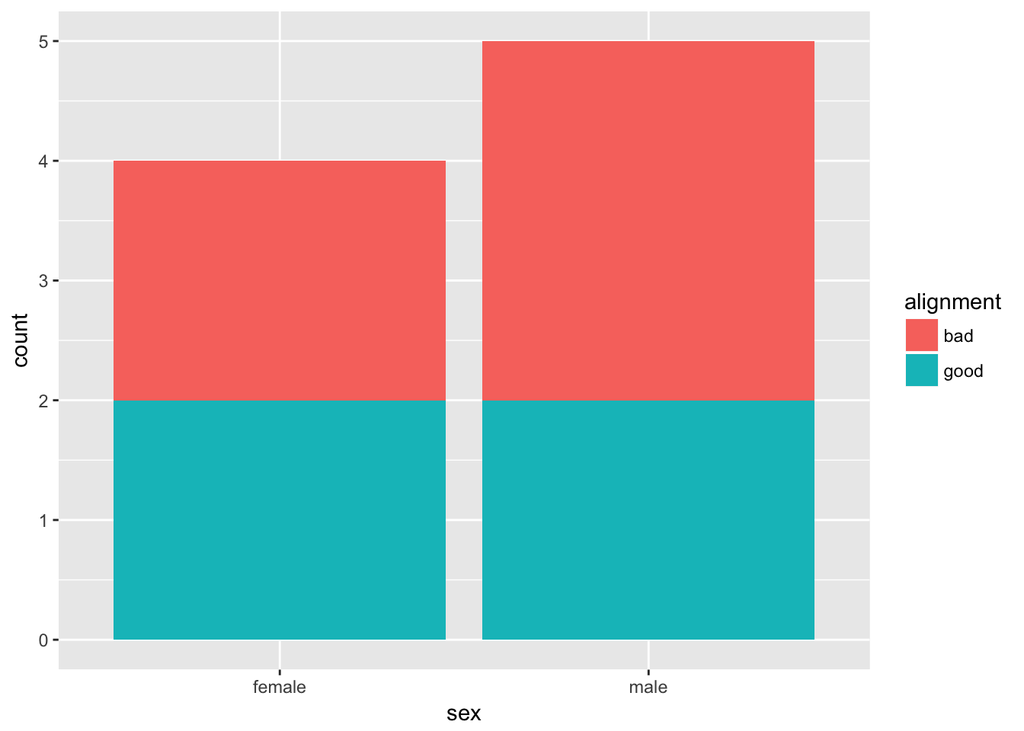

```r
superAnti %>% ggplot(aes(sex)) +
  geom_bar(aes(fill=alignment))
```

# Exercise:

## How about our spread full-joined result?

## Our spread inner-joined result?

## How can we handle NA’s?

## QUESTION 2: WHO’S OLDER AND YOUNGER THAN BATMAN?

### Lollipop charts

[figure not shown]

```r
superAnti %>% ggplot(aes(x=name, y=age, label=age )) +
  geom_point(stat='identity', fill="black", size=8) +
  geom_segment(aes(y = 0,
                   x = name,
                   yend = age,
                   xend= name),
               color = "black") +
  coord_flip()
```

Loki is throwing things off here. Let’s take him out:

[figure not shown]

```r
superAnti %>% filter(name != "Loki") %>% ggplot(aes(x=name, y=age, label=age )) +
  geom_point(stat='identity', fill="black", size=8) +
  geom_segment(aes(y = 0,
                   x = name,
                   yend = age,
                   xend= name),
               color = "black") +
  coord_flip()
```

Much better!

Let’s add a little text in the dots for clarity and set our ‘baseline’ age to 32:

[figure not shown]

```r
superAnti %>% filter(name != "Loki") %>% ggplot(aes(x=name, y=age, label=age )) +
  geom_point(stat='identity', fill="black", size=8) +
  geom_segment(aes(y = 32,
                   x = name,
                   yend = age,
                   xend= name),
               color = "black") +
                geom_text(color="white", size=3)+
  labs(title="Who's older and younger than the Batman?", subtitle="Batman is 32")+
  coord_flip()
```